# SemiCor Functions

Ishaan Gadiyar

2026-02-05

# 1 Introduction

The aim of this tutorial is to show users how to download the *semicor* package and how to appropriately use the functions available in the package. While this specific tutorial uses a neuroimaging dataset to train and evaluate random forest and ridge regression models, *semicor* can be used across a variety of black-box models that predict continuous outcomes.

# 2 Loading Packages/Libraries

```r
library(tidyverse)
library(knitr)
library(glmnet)
library(locfit)
library(ggplot2)
library(ranger)
library(tuneRanger)
library(mlr)
library(dplyr)

# Installing and loading semicor package
if (!"semicor" %in% rownames(installed.packages())) {
  devtools::install_github("statimagcoll/semicor", upgrade = "never")
}
library(semicor)

# Setting the seed
set.seed(123)

# Remove this later
source("/media/disk2/multivariateBWAS/code_for_review/build_funcs.R")
# Sourcing influence and correlation functions
source("/media/disk2/multivariateBWAS/code_for_review/influence_funcs.R")
source("/media/disk2/multivariateBWAS/code_for_review/corr_funcs.R")
```

# 3 Methods

## 3.1 foldOS: A Cross-Fitting Function

Here, *foldOS* is a function that handles cross-fitting for a variety of models. It can be called directly from the *semicor* package, and the code is provided below.

```r
foldOS <- function(y, y_hat, folds, y_hat2 = NULL, level = 0.95){
  # Sanity Check
  if(length(y_hat) != length(y) | length(y_hat) != length(folds) | length(y) != length(folds)){
    stop("y, y_hat, and folds must be of the same length.")
  }

  # Creating storage vector for results and variables
  os_folds = c()
  inf_folds = c()
  n = length(y)

  # Looping through folds
  for(fold in unique(folds)){
    # Calculating and storing OS estimator
    os_res = cor_os(y_hat[which(folds == fold)], y[which(folds == fold)])
    os_folds = c(os_folds, os_res)

    # Calculating the influence vector and storing
    inf_res = if_logit_sq(y_hat[which(folds == fold)], y[which(folds == fold)])
    inf_folds = c(inf_folds, inf_res)
  }

  # Calculating overall OS estimate
  os_estimate = mean(os_folds, na.rm = T)

  # Calculating the standard error
  stand_error = sqrt(var(inf_folds)/n)

  # Calculating the bounds
  LB_est = sqrt(expit(logit(os_estimate^2) - qnorm((1 + level) / 2)*stand_error))
  UB_est = sqrt(expit(logit(os_estimate^2) - qnorm((1 - level) / 2)*stand_error))

  # Formatting fold estimates for output
  names(os_folds) <- unique(folds)

  # Creating data frame output
  estimate = data.frame(est = os_estimate, LB = LB_est, UB = UB_est, se = stand_error)


  if(!is.null(y_hat2)){
    # Sanity Check
    if(length(y_hat2) != length(y) | length(y_hat2) != length(folds) | length(y) != length(folds)){
      stop("y, y_hat2, and folds must be of the same length.")
    }

    # Creating storage vector for results and variables
    os_folds2 = c()
    inf_folds2 = c()
    n = length(y)

    # Looping through folds
    for(fold in unique(folds)){
      # Calculating and storing OS estimator
      os_res = cor_os(y_hat2[which(folds == fold)], y[which(folds == fold)])
      os_folds2 = c(os_folds2, os_res)

      # Calculating the influence vector and storing
      inf_res = if_logit_sq(y_hat2[which(folds == fold)], y[which(folds == fold)])
      inf_folds2 = c(inf_folds2, inf_res)
    }

    # Calculating overall OS estimate
    os_estimate2 = mean(os_folds2, na.rm = T)

    # Calculating standard error
    stand_error2 = sqrt(var(inf_folds2)/n)

    # Calculating the bounds
    LB_est2 = sqrt(expit(logit(os_estimate2^2) - qnorm((1 + level) / 2)* stand_error2))
    UB_est2 = sqrt(expit(logit(os_estimate2^2) - qnorm((1 - level) / 2)*stand_error2))

    # Formatting fold estimates for output
    names(os_folds2) <- unique(folds)

    # Creating data frame output
    estimate2 = data.frame(est = os_estimate2, LB = LB_est2, UB = UB_est2, se = stand_error2)

    # Calculating OS difference - first yhat vs. second yhat
    diff = cor_os_diff(os_estimate, os_estimate2, inf_folds, inf_folds2)
    os_diff = data.frame(est = diff[1], LB = diff[2], UB = diff[3], se = NA)

    # Calculating the OS ratio - first yhat vs. second yhat
    ratio = cor_os_ratio(os_estimate, os_estimate2, inf_folds, inf_folds2)
    os_ratio = data.frame(est = ratio[1], LB = ratio[2], UB = ratio[3], se = NA)

    # Combining all data into one
    est_total = rbind(estimate, estimate2, os_diff, os_ratio)

    # Assigning row names
    est_total$metric <- c("yhat1", "yhat2", "Diff", "Ratio")
    rownames(est_total) <- NULL


    # Combining all outputs into one list
    out = list(est = est_total, fold.est = os_folds, fold.est2 = os_folds2, n = n, conf.level = level) # data frame version
  }
  else{
    # Combining all outputs into one list when there is no yhat2
    out = list(est = estimate, fold.est = os_folds, n = n, conf.level = level) # data frame version
  }

  # Returning the data frame
  return(out)
}
```

## 3.2 sampleSplitOS: A Sample-Split Function

Here, sampleSplitOS allows calls on the *foldOS* function and allows users to perform sample splits on top of cross-fitting. It can be called directly from the *semicor* package, and the code is provided below.

```r
sampleSplitOS <- function(y, y_hat, folds, y_hat2 = NULL, level = 0.95){
  # Turning y into a matrix
  y = as.matrix(y)

  # Turning data frames into matrices
  if(is.data.frame(y_hat)){
    y_hat = as.matrix(y_hat)
  }

  if(is.data.frame(folds)){
    folds = as.matrix(folds)
  }

  if(is.data.frame(y_hat2)){
    y_hat2 = as.matrix(y_hat2)
  }

  # Sanity checks
  if(nrow(y) != nrow(y_hat) | nrow(y) != nrow(folds) | nrow(folds) != nrow(y_hat)){
    stop("y and y_hat must have the same amount of rows")
  }

  if(ncol(folds) != ncol(y_hat)){
    stop("folds and y_hat must have the same column number")
  }

  # Sanity checks for second mu
  if(!is.null(y_hat2)){
      if(ncol(folds) != ncol(y_hat2)){
      stop("folds and y_hat2 must have the same column number")
    }

    if(nrow(y) != nrow(y_hat2) | nrow(folds) != nrow(y_hat2)){
      stop("y and y_hat2 must have the same amount of rows")
    }
  }


  # number of sample splits
  n_splits <- ncol(y_hat)


  # Gathering results
  res_list <- lapply(seq_len(n_splits), function(i) {
    tmp <- foldOS(y, y_hat[, i], folds[, i], y_hat2[,i], level)
    tmp$est$split <- i

    list(
      est   = tmp$est,
      fold1 = tmp$fold.est,
      fold2 = if (is.null(y_hat2)) NULL else tmp$fold.est2
    )
  })

  # Combining all results
  out <- list(
    est        = do.call(rbind, lapply(res_list, `[[`, "est")),
    fold1.vals = do.call(rbind, lapply(res_list, `[[`, "fold1")),
    n          = length(y),
    conf.level = level
  )

  if (!is.null(y_hat2)) {
    out$fold2.vals <- do.call(rbind, lapply(res_list, `[[`, "fold2"))
  }

  # Returning output
  return(out)
}
```

# 4 Installing Data

Here, we utilize data from the *NeuroDataSets* package in R. More specifically, this tutorial will use the *OASIS_cross_tbl_df*, a subset of data taken from the Open Access Series of Imaging Studies (OASIS) datasets available from WashU Medicine.

In the OASIS_cross_tbl_df, the pertinent data that we use are: - Age: a continuous measure in years that represents how old a subject’s brain is. We predict this measure in both model examples. - eTIV: representative of the estimated total intracranial volume, which is a structural brain measure. - nWBV: representative of the normalized whole-brain volume, which is a structural brain measure. - ASF: representative of the atlas scaling factor, which represents the volume-scaling adjustment needed to align an individual’s brain to a standard template.

```r
# Setting the seed
set.seed(123)

# Loading in dataset
library(NeuroDataSets)

# Loading in dataset of interest
data("OASIS_cross_tbl_df")

# Previewing the data
head(OASIS_cross_tbl_df)
```

```
## # A tibble: 6 × 12
##   ID           `M/F` Hand    Age  Educ   SES  MMSE   CDR  eTIV  nWBV   ASF Delay
##   <chr>        <chr> <chr> <dbl> <dbl> <dbl> <dbl> <dbl> <dbl> <dbl> <dbl> <chr>
## 1 OAS1_0001_M… F     R        74     2     3    29   0    1344 0.743  1.31 N/A
## 2 OAS1_0002_M… F     R        55     4     1    29   0    1147 0.81   1.53 N/A
## 3 OAS1_0003_M… F     R        73     4     3    27   0.5  1454 0.708  1.21 N/A
## 4 OAS1_0004_M… M     R        28    NA    NA    NA  NA    1588 0.803  1.10 N/A
## 5 OAS1_0005_M… M     R        18    NA    NA    NA  NA    1737 0.848  1.01 N/A
## 6 OAS1_0006_M… F     R        24    NA    NA    NA  NA    1131 0.862  1.55 N/A
```

# 5 Ridge Regression Model Examples

This section seeks to highlight how the *semicor* package can be used to evaluate ridge regression models in two instances where 1) a model is only trained on cross-fold validation or 2) a model is trained with cross-fold validation and sample splits.

## 5.1 Ridge Regression Example with only Cross-Fold Validation

### 5.1.1 Training the Model

Here, we test how the inclusion of either eTIV or nWBV in a ridge regression model impacts model accuracy when predicting age.

```r
# Cleaning data - drop NA before CV
data_clean = OASIS_cross_tbl_df %>% drop_na(Age)

# Assigning folds randomly
folds = 5
data_clean$fold <- sample(rep(1:folds, length.out = nrow(data_clean)))

# Sanity check for fold distribution
table(data_clean$fold)
```

```
##
##  1  2  3  4  5
## 88 87 87 87 87
```

```r
# Creating storage variables
lambda_eTIV = c()
lambda_nWBV = c()

# Creating storage columns
data_clean$preds_eTIV = NA
data_clean$preds_nWBV = NA

# Creating a for loop for 5-fold cross validation
for(i in 1:folds){
  # Assigning data
  test = data_clean %>% filter(fold == i)
  train = data_clean %>% filter(fold != i)

  # Creating model data variables for training
  x_var_eTIV = as.matrix(train[, colnames(data_clean) %in% c("eTIV", "ASF")])
  y_var = as.matrix(train[, colnames(data_clean) %in% c("Age")])
  x_var_nWBV = as.matrix(train[, colnames(data_clean) %in% c("nWBV", "ASF")])

  # Creating model variables for prediction
  newx_eTIV = as.matrix(test[, colnames(data_clean) %in% c("eTIV", "ASF")])
  newx_nWBV = as.matrix(test[, colnames(data_clean) %in% c("nWBV", "ASF")])
  newy = as.matrix(test[, colnames(data_clean) %in% c("Age")])

  # Fitting a ridge regression model
  lambda_seq <- c(
    seq(10, 1, -1),        # From 10 to 1 (step of 1)
    seq(0.9, 0.1, -0.1),   # From 0.9 to 0.1 (step of 0.1)
    seq(0.09, 0.01, -0.01),# From 0.09 to 0.01 (step of 0.01)
    seq(0.009, 0.001, -0.001), # From 0.009 to 0.001 (step of 0.001)
    seq(0.0009, 0.0001, -0.0001), # From 0.0009 to 0.0001 (step of 0.0001)
    seq(0.00009, 0.00001, -0.00001), # From 0.00009 to 0.00001
    seq(0.000009, 0.000001, -0.000001), # From 0.000009 to 0.000001
    seq(0.0000009, 0.0000001, -0.0000001), # From 0.0000009 to 0.0000001
    0
  )

  # Training respective models
  ridgeModel_eTIV <- cv.glmnet(x_var_eTIV, y_var, alpha = 0, lambda = lambda_seq)
  ridgeModel_nWBV <- cv.glmnet(x_var_nWBV, y_var, alpha = 0, lambda = lambda_seq)

  # Getting predictions
  test$preds_eTIV = predict(ridgeModel_eTIV, newx = newx_eTIV, s = "lambda.min")[,]
  test$preds_nWBV = predict(ridgeModel_nWBV, newx = newx_nWBV, s = "lambda.min")[,]

  # Storing prediction values
  ## Isolating to a singular data frame with only the prediction values and IDs
  test_collapsed <- test %>%
  group_by(ID) %>%
  summarise(
    preds_eTIV = first(na.omit(preds_eTIV)),
    preds_nWBV = first(na.omit(preds_nWBV)),
    .groups = "drop"
  )

  ## Matching the predictions by ID to the original data frame
  data_clean <- data_clean %>%
  left_join(test_collapsed, by = "ID", suffix = c("", "_new"))%>%
  mutate(
    preds_eTIV = ifelse(is.na(preds_eTIV_new), preds_eTIV, preds_eTIV_new),
    preds_nWBV = ifelse(is.na(preds_nWBV_new), preds_nWBV, preds_nWBV_new)
  ) %>%
  select(-ends_with("_new"))


  # Storing minimum lambda used for each ridge regression model
  lambda_eTIV = c(lambda_eTIV, ridgeModel_eTIV$lambda.min)
  lambda_nWBV = c(lambda_nWBV, ridgeModel_nWBV$lambda.min)
}
```

### 5.1.2 Applying Semicor to Data Predictions

```r
# Gathering the estimates with one sample split
results = sampleSplitOS(as.matrix(data_clean$Age), as.matrix(data_clean$preds_eTIV), as.matrix(data_clean$fold), as.matrix(data_clean$preds_nWBV))

# Here, yhat1 represents the prediction accuracy of the eTIV model and
# yhat2 represents the prediction accuracy of the nWBV model
results$est <- results$est %>% mutate(metric = recode(metric, yhat1 = "eTIV Model", yhat2 = "nWBV Model"))
```

### 5.1.3 Graphing Outputs

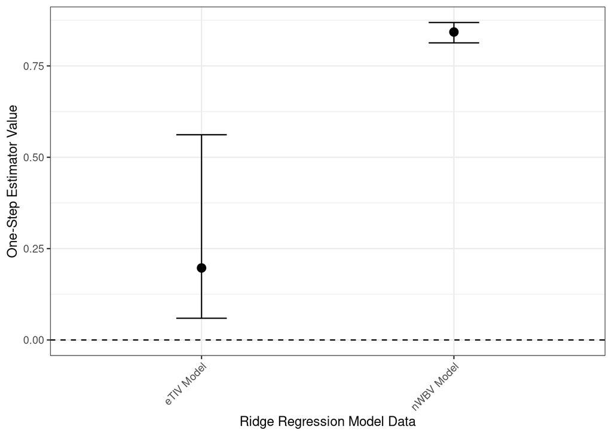

```r
# Subsetting results to only estimates
toPlot = results$est %>% filter(metric == "eTIV Model" | metric == "nWBV Model")
toPlot_Diff =  results$est %>% filter(metric == "Diff")

# Plotting one-step results
ggplot(toPlot, aes(x = metric, y = est)) +
  geom_point(position = position_dodge(width = 0.5), size = 3) +
  geom_errorbar(aes(ymin = LB, ymax = UB),
                width = 0.2,
                position = position_dodge(width = 0.5)) +
  theme_bw() +
  theme(axis.text.x = element_text(angle = 45, hjust=1)) +
  geom_hline(yintercept = 0, linetype = "dashed", color = "black")  +
  labs(x = "Ridge Regression Model Data", y = "One-Step Estimator Value")
```

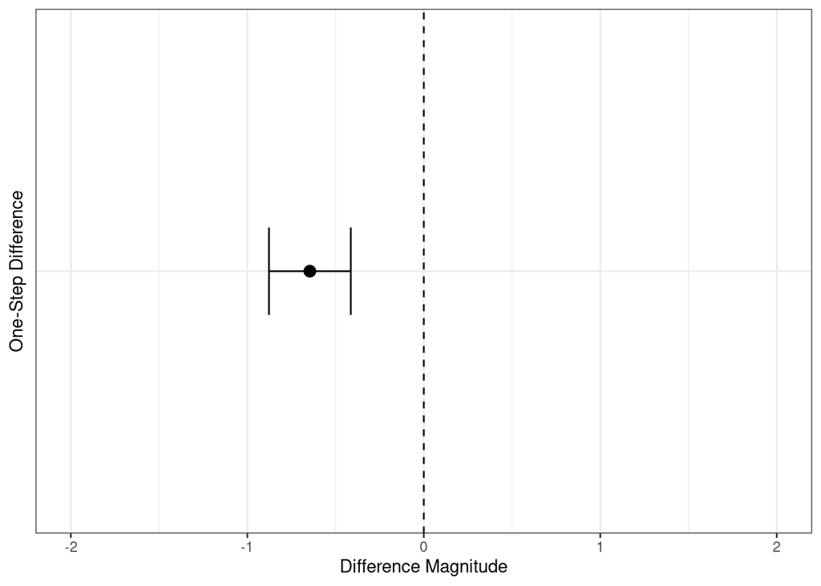

```r
# Plotting one-step difference results
ggplot(toPlot_Diff, aes(x = metric, y = est)) +
  geom_point(position = position_dodge(width = 0.5), size = 3) +
  geom_errorbar(aes(ymin = LB, ymax = UB),
                width = 0.2,
                position = position_dodge(width = 0.5)) +
  theme_bw() +
  theme(axis.ticks.y = element_blank(), axis.text.y = element_blank()) +
  coord_flip() +
  geom_hline(yintercept = 0, linetype = "dashed", color = "black")  +
  ylim(-2,2) +
  labs(x = "One-Step Difference", y = "Difference Magnitude")
```

### 5.1.4 Analysis

Here, we see that the inclusion of normalized whole-brain volume (nWBV) instead of estimated total intracranial volume (eTIV) leads to a significantly higher model prediction accuracy for the continuous variable age. This indicates that in neuroimaging prediction studies for age, scientisits should consider using nWBV over eTIV to predict brain age phenotype.